# Pre processing GSE125416

GSE125416 is an experiment comparing normal hESC cells and nicotine exposed hESC cells. High rate of cell cycle is expected. It contains two samples:

- GSM3573649 Control_EB scRNA-seq [D];
- GSM3573650 nicotine-exposed_EB scRNA-seq [N].

Data is accessible at [Gene Expression Omnibus - GSE125416](https://www.ncbi.nlm.nih.gov/geo/query/acc.cgi?acc=GSE125416).

Article is accessible at [Stem Cell Reports - Single-Cell RNA Sequencing of Human Embryonic Stem Cell Differentiation Delineates Adverse Effects of Nicotine on Embryonic Development](https://www.sciencedirect.com/science/article/pii/S2213671119300244)

# Read data

We use Seurat to read and preprocess the data.

```r
library(Seurat)
filepath = "/home/shaoheng/Documents/data/hESC-droplet/GSE125416/GSM3573649_D_filtered_gene_bc_matrices_h5.h5"
obj = CreateSeuratObject(Read10X_h5(filepath), project='wt')
```

```
Feature names cannot have underscores ('_'), replacing with dashes ('-')
```

```r
obj
```

```
An object of class Seurat
33694 features across 6847 samples within 1 assay
Active assay: RNA (33694 features)
```

# Filtering

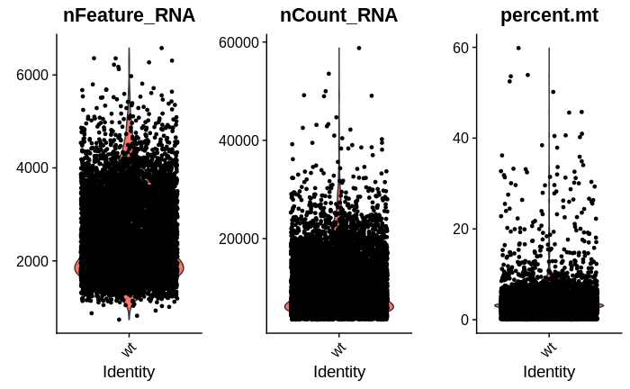

```r
obj[["percent.mt"]] <- PercentageFeatureSet(obj, pattern = "^MT-")
VlnPlot(obj, features = c("nFeature_RNA", "nCount_RNA", "percent.mt"), ncol = 3)
```

## Mitochondria and expressed genes

“cells with fewer than 200 or more than 6,000 expressed genes, and a high percentage of mitochondrial genes (>20%) were removed.” This is done by `subset`. Should keep 6766 cells.

```r
obj <- subset(obj, subset = nFeature_RNA >= 200 & nFeature_RNA <= 6000 & percent.mt < 20)
obj
```

```
An object of class Seurat
33694 features across 6766 samples within 1 assay
Active assay: RNA (33694 features)
```

## Normalization

“We next normalized the gene expression values for each cell by the total expression, multiplied by 10,000, and made a log-transformation.” This is done by `NormalizeData`.

```r
obj <- NormalizeData(obj)
```

## Variable genes

Variable expressed genes across the single cells under cutoff with an average expression of more than 0.0125 and less than 3, and dispersion of more than 0.5, were detected for down-stream analysis.

```r
obj <- FindVariableFeatures(obj, mean.cutoff = c(0.0125, 3), dispersion.cutoff = c(0.5, Inf))
```

## Cell cycle

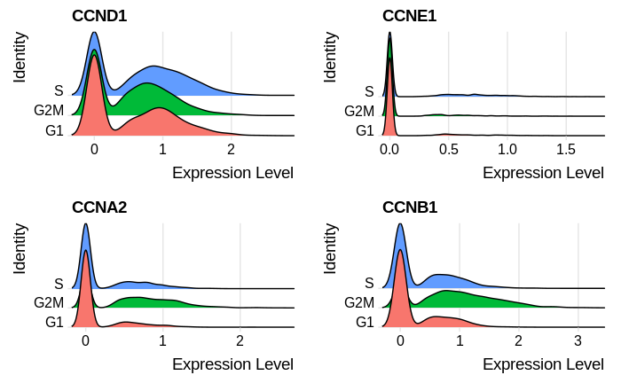

```r
obj <- CellCycleScoring(obj, s.features = cc.genes$s.genes, g2m.features = cc.genes$g2m.genes, set.ident = TRUE)
RidgePlot(obj, features = c("CCND1", "CCNE1", "CCNA2", "CCNB1"), ncol = 2)
```

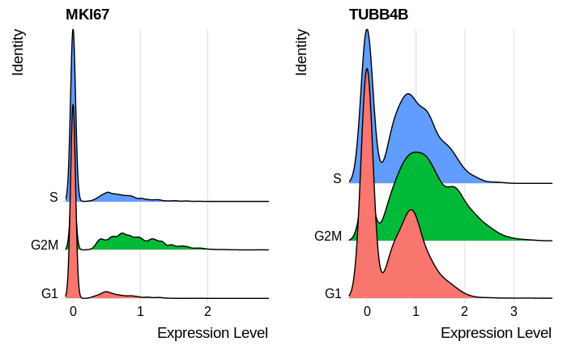

```r
RidgePlot(obj, features = c("MKI67", "TUBB4B"), ncol = 2)
```

## PCA

```r
obj <- ScaleData(obj, features = rownames(obj))
```

```r
obj <- RunPCA(obj, features = VariableFeatures(object = obj))
```

```
PC_ 1
Positive:  DLK1, VIM, PRSS23, METRN, TMSB15A, COL2A1, SIX3, ZNF436-AS1, IGFBP5, PAX6
       CRABP1, MEST, NNAT, MALAT1, LHX2, SFRP2, TPBG, EFNA5, SIX6, HES1
       RBP1, RAX, FABP7, SOX3, TTC3, PTN, IGFBP2, RP11-89K21.1, ARL4C, FRZB
Negative:  POU5F1, CLDN6, CD24, TERF1, RP11-148B6.1, RP11-568A7.4, PDLIM1, PLA2G16, TMSB4X, TDGF1
       RP11-1144P22.1, UTF1, SCGB3A2, L1TD1, RARRES2, FOXH1, UGP2, IFITM1, EPCAM, PTMA
       PODXL, NMRK2, CLDN7, DNMT3B, PFN1, FRAT2, CARHSP1, PMAIP1, EZR, SEPP1
PC_ 2
Positive:  HMGB1, CKS1B, PTTG1, HMGB2, CKS2, BIRC5, UBE2C, UBE2S, RANBP1, CENPF
       NUCKS1, TOP2A, FAM64A, CALM2, MKI67, HN1, HSPE1, NUSAP1, MT-CO3, CDC20
       MT-ATP6, MT-CO2, CCNA2, CDKN3, HIST1H4C, AURKB, RAN, TPX2, AURKA, PTMA
Negative:  S100A11, ANXA2, ANXA1, NEAT1, CLDN4, GDF15, DDIT3, KRT19, SAT1, S100A6
       LGALS3, KRT8, S100A10, IGF2, PLAU, ELF3, ANXA3, VGLL1, CDKN1A, TAC1
       S100A16, SGCG, TACSTD2, KRT18, TMEM40, PRSS8, FXYD3, CLDN3, CD70, S100A14
PC_ 3
Positive:  RPL8, TDGF1, RPSA, RP11-1144P22.1, FTL, PLA2G16, LINC00678, PMAIP1, NMRK2, PIM2
       CHCHD10, RP11-568A7.4, UTF1, C9orf135, POU5F1, FOXD3-AS1, FOXH1, ZFAS1, RPL12, NANOG
       TCEA1, GAL, IFITM3, FXYD5, BBC3, DDIT3, MIAT, RP11-35J1.2, DDIT4, AKIRIN1
Negative:  HAPLN1, S100A11, TMSB10, KRT8, SEMA3E, KRT19, TFAP2A, CLDN4, DLX5, CXCL14
       CENPF, TUBA1B, HSP90AA1, TUBB4B, KRT18, GATA3, LY6E, MKI67, MT-CYB, HMGB1
       HSP90B1, ARL6IP1, WNT6, VGLL1, CENPW, TOP2A, NUCKS1, CADM1, S100A16, MT-ND2
PC_ 4
Positive:  MT-CO1, MT-ND4, MT-CO3, MT-ND1, MT-CO2, MT-ND2, MT-ATP6, MT-CYB, MT-ND3, MT-ND5
       PODXL, IRX2, TMSB4X, JARID2, CDH1, PWAR6, KCNK12, TMSB10, PTPRF, GJA1
       LIN28A, TRIM71, INSR, B3GNT7, FGFR1, TMEM54, FGFR3, MT-ND6, PPP1R14B, USP9X
Negative:  TUBA1B, ENO1, GAPDH, KPNA2, TPI1, CALM2, TUBA1A, UBC, PHGDH, ATP5B
       TUBB4B, CDC20, ALDOA, CCNB1, RAN, ACTB, UCHL1, EIF1, HSP90AA1, PGK1
       HSP90AB1, PSAT1, PSMA4, HSPA8, LDHA, CCNB2, CKB, PSMB1, PRDX1, CCT5
PC_ 5
Positive:  TOP2A, UBE2C, CENPA, PIF1, CENPF, MKI67, UBE2S, TPX2, PSRC1, PLK1
       AURKA, CDKN3, GTSE1, ASPM, HMGB2, MALAT1, CDCA3, CKS2, ARL6IP1, NUSAP1
       CDK1, NEAT1, SGOL2, KNSTRN, FAM64A, PRC1, RNF26, CKAP2L, AURKB, CENPE
Negative:  ENO1, GAPDH, ACTB, HSP90AB1, PRDX1, TPI1, MYL6, PGAM1, PSMB1, ALDOA
       ACAT2, PGK1, ATP5B, PSMB6, PSMA4, LHX5-AS1, RAN, C1QBP, HSP90AA1, NDUFA4
       PHGDH, HSPD1, CDC123, CCT5, SSB, SSBP1, RANBP1, HESX1, CALM1, PFN1
```

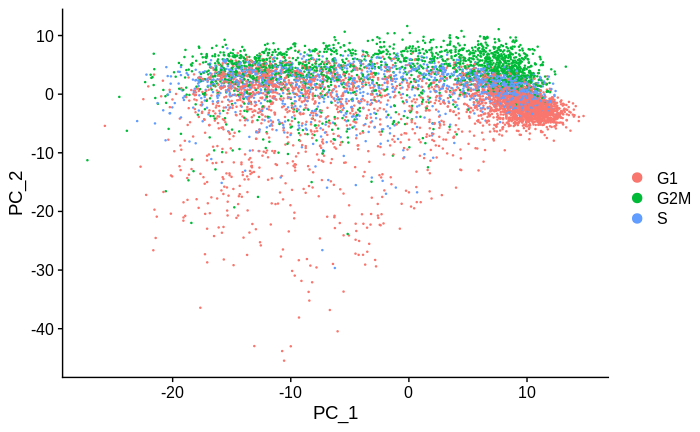

```r
DimPlot(obj)
```

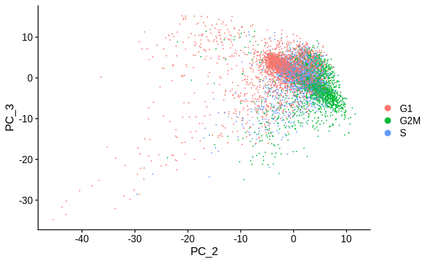

```r
DimPlot(obj, dims = c(2, 3), pt.size=0.1)
```

```r
saveRDS(obj, "~/Documents/data/hESC-droplet/GSE125416/GSM357649-regular.RDS")
```

```r
source("../utils/gsea.R")
mat2cls(as.matrix(obj@reductions$pca@cell.embeddings), "~/Documents/data/hESC-droplet/GSE125416/GSM357649-regular-pca.cls")
```